```python
#importing all the required libraries for implementing Clustering Algorithm
import pandas as pd
import numpy as np
import missingno as msno
!pip install git+https://github.com/crew102/validclust.git
import seaborn as sns
import matplotlib.pyplot as plt
from scipy import stats
import scipy.cluster.hierarchy as shc
%matplotlib inline
import sklearn
from sklearn.metrics import pairwise_distances
from validclust import dunn
from sklearn.preprocessing import MinMaxScaler
```

```
  Cloning https://github.com/crew102/validclust.git to /tmp/pip-req-build-iulx1jmm
  Running command git clone -q https://github.com/crew102/validclust.git /tmp/pip-req-build-iulx1jmm
```

```python
df = pd.read_csv("World Indicators.csv")
```

# **Exploratory Data Analysis and Data Wrangling**

```python
df.head(5)
```

|  | Birth Rate | Business Tax Rate | Days to Start Business | Energy Usage | GDP | Health Exp % GDP | Health Exp/Capita | Hours to do Tax | Infant Mortality Rate | Internet Usage | Lending Interest | Life Expectancy Female | Life Expectancy Male | Mobile Phone Usage | Population 0-14 | Population 15-64 | Population 65+ | Population Urban | Region | Country |
| --- | --- | --- | --- | --- | --- | --- | --- | --- | --- | --- | --- | --- | --- | --- | --- | --- | --- | --- | --- | --- |
| 0 | 0.025 | 72.0% | 25.0 | 41852.0 | $199,070,864,638 | 0.044 | $233 | 451.0 | 0.023 | 0.1 | 0.080 | 72.0 | 69.0 | 0.9 | 0.272 | 0.681 | 0.047 | 0.682 | Africa | Algeria |
| 1 | 0.046 | 52.1% | 66.0 | 13576.0 | $104,115,863,405 | 0.034 | $178 | 282.0 | 0.107 | 0.1 | 0.188 | 53.0 | 50.0 | 0.5 | 0.477 | 0.499 | 0.024 | 0.409 | Africa | Angola |
| 2 | 0.037 | 65.9% | 29.0 | 3761.0 | $7,294,900,431 | 0.045 | $34 | 270.0 | 0.060 | 0.0 | NaN | 60.0 | 58.0 | 0.8 | 0.432 | 0.539 | 0.029 | 0.423 | Africa | Benin |
| 3 | 0.024 | 19.5% | 60.0 | 2215.0 | $15,292,424,757 | 0.052 | $404 | 152.0 | 0.039 | 0.1 | 0.110 | 46.0 | 47.0 | 1.5 | 0.340 | 0.625 | 0.035 | 0.565 | Africa | Botswana |
| 4 | 0.042 | 43.5% | 13.0 | NaN | $10,395,757,480 | 0.064 | $39 | 270.0 | 0.068 | 0.0 | NaN | 56.0 | 55.0 | 0.5 | 0.458 | 0.517 | 0.025 | 0.265 | Africa | Burkina Faso |

```python
df.describe()
```

|  | Birth Rate | Days to Start Business | Energy Usage | Health Exp % GDP | Hours to do Tax | Infant Mortality Rate | Internet Usage | Lending Interest | Life Expectancy Female | Life Expectancy Male | Mobile Phone Usage | Population 0-14 | Population 15-64 | Population 65+ | Population Urban |
| --- | --- | --- | --- | --- | --- | --- | --- | --- | --- | --- | --- | --- | --- | --- | --- |
| count | 199.000000 | 181.000000 | 1.360000e+02 | 185.000000 | 180.000000 | 188.000000 | 199.000000 | 131.000000 | 197.000000 | 197.000000 | 196.000000 | 191.000000 | 191.000000 | 191.000000 | 206.000000 |
| mean | 0.021759 | 30.331492 | 9.223794e+04 | 0.067362 | 279.283333 | 0.027340 | 0.376884 | 0.122588 | 72.746193 | 68.035533 | 0.958673 | 0.286963 | 0.635550 | 0.077424 | 0.576728 |
| std | 0.010721 | 56.584357 | 3.125758e+05 | 0.028462 | 247.783296 | 0.025358 | 0.284034 | 0.079495 | 10.091750 | 8.868297 | 0.431784 | 0.107775 | 0.071489 | 0.052995 | 0.244372 |
| min | 0.008000 | 1.000000 | 7.650000e+02 | 0.017000 | 12.000000 | 0.002000 | 0.000000 | 0.005000 | 45.000000 | 45.000000 | 0.000000 | 0.119000 | 0.475000 | 0.003000 | 0.089000 |
| 25% | 0.012000 | 9.000000 | 5.699000e+03 | 0.047000 | 151.750000 | 0.007000 | 0.100000 | 0.074500 | 67.000000 | 62.000000 | 0.700000 | 0.189000 | 0.581000 | 0.034000 | 0.377750 |
| 50% | 0.019000 | 18.000000 | 1.808200e+04 | 0.065000 | 224.000000 | 0.016000 | 0.400000 | 0.106000 | 76.000000 | 70.000000 | 1.000000 | 0.279000 | 0.654000 | 0.056000 | 0.571500 |
| 75% | 0.028000 | 35.000000 | 5.155725e+04 | 0.085000 | 327.000000 | 0.042250 | 0.600000 | 0.150000 | 80.000000 | 75.000000 | 1.200000 | 0.382500 | 0.684500 | 0.118000 | 0.772500 |
| max | 0.050000 | 694.000000 | 2.727728e+06 | 0.177000 | 2600.000000 | 0.112000 | 0.900000 | 0.525000 | 87.000000 | 81.000000 | 2.500000 | 0.499000 | 0.857000 | 0.237000 | 1.000000 |

```python
#finding out if any columns have any null values
df.info()
```

```
<class 'pandas.core.frame.DataFrame'>
RangeIndex: 208 entries, 0 to 207
Data columns (total 20 columns):
 #   Column                  Non-Null Count  Dtype
---  ------                  --------------  -----
 0   Birth Rate              199 non-null    float64
 1   Business Tax Rate       181 non-null    object
 2   Days to Start Business  181 non-null    float64
 3   Energy Usage            136 non-null    float64
 4   GDP                     188 non-null    object
 5   Health Exp % GDP        185 non-null    float64
 6   Health Exp/Capita       185 non-null    object
 7   Hours to do Tax         180 non-null    float64
 8   Infant Mortality Rate   188 non-null    float64
 9   Internet Usage          199 non-null    float64
 10  Lending Interest        131 non-null    float64
 11  Life Expectancy Female  197 non-null    float64
 12  Life Expectancy Male    197 non-null    float64
 13  Mobile Phone Usage      196 non-null    float64
 14  Population 0-14         191 non-null    float64
 15  Population 15-64        191 non-null    float64
 16  Population 65+          191 non-null    float64
 17  Population Urban        206 non-null    float64
 18  Region                  208 non-null    object
 19  Country                 208 non-null    object
dtypes: float64(15), object(5)
memory usage: 32.6+ KB
```

```python
# Calculating the % of missing values
df.isnull().sum()/len(df)*100
```

```
Birth Rate                 4.326923
Business Tax Rate         12.980769
Days to Start Business    12.980769
Energy Usage              34.615385
GDP                        9.615385
Health Exp % GDP          11.057692
Health Exp/Capita         11.057692
Hours to do Tax           13.461538
Infant Mortality Rate      9.615385
Internet Usage             4.326923
Lending Interest          37.019231
Life Expectancy Female     5.288462
Life Expectancy Male       5.288462
Mobile Phone Usage         5.769231
Population 0-14            8.173077
Population 15-64           8.173077
Population 65+             8.173077
Population Urban           0.961538
Region                     0.000000
Country                    0.000000
dtype: float64
```

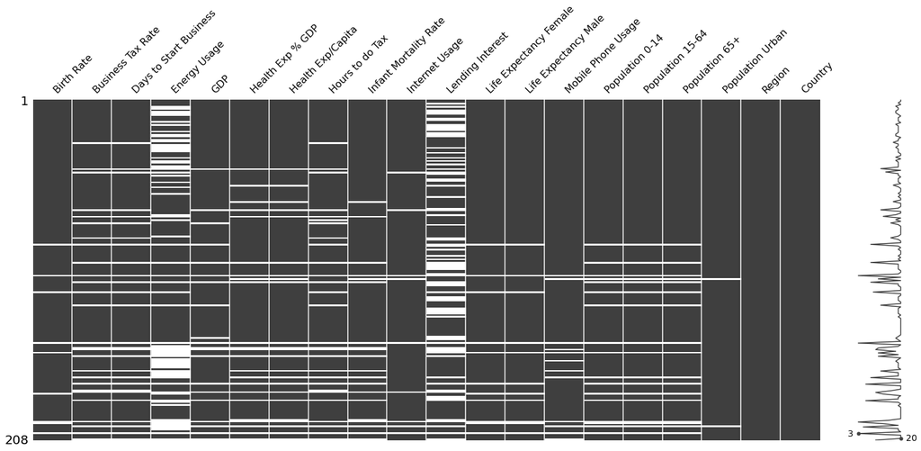

```python
# Visualize the missing values using a matrix
msno.matrix(df)
```

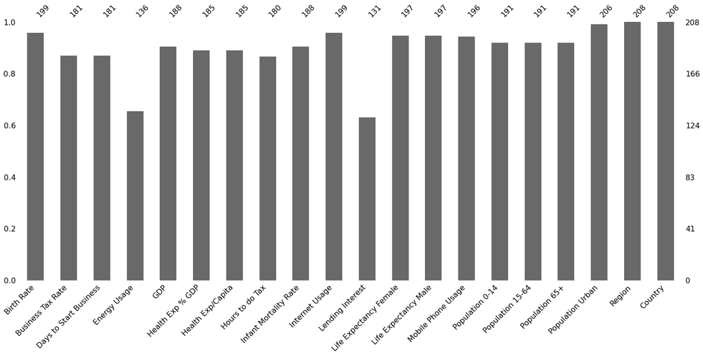

```python
#Bar plot for count of each columns
msno.bar(df)
```

```python
# Dropping the rows that have  null values>=80%
percentage = 80
min_count =  int(((100-percentage)/100)*df.shape[1] + 1)
df = df.dropna( axis=0,thresh=min_count)
```

```python
#Dropping the coluumns Lending Interest. and 'Energy Usage due to higher %. of  null values
df.drop(columns = ['Lending Interest','Energy Usage'], inplace=True)
```

```python
# Cleaning the data for further caluations
df["Business Tax Rate"] = df["Business Tax Rate"].replace({'\%':'', ',':''}, regex=True).astype(float)
df['Business Tax Rate']=df['Business Tax Rate']/100
df["GDP"] = df["GDP"].replace({'\$':'', ',':''}, regex=True).astype(float)
df["Health Exp/Capita"] = df["Health Exp/Capita"].replace({'\$':'', ',':''}, regex=True).astype(float)
```

```python
#Replacing the null values with region wise median
k=list(df.columns)[:-2]
print(k)
# Imputing for missing values
for i in df[k]:
    if df[i].isnull().sum()==0:
        continue


    else:
        replacer=df.groupby('Region')[i].median()
        for b in df.Region.unique():
            df[i].loc[(df[i].isnull())&(df['Region']==b)]=replacer[b]
```

```
['Birth Rate', 'Business Tax Rate', 'Days to Start Business', 'GDP', 'Health Exp % GDP', 'Health Exp/Capita', 'Hours to do Tax', 'Infant Mortality Rate', 'Internet Usage', 'Life Expectancy Female', 'Life Expectancy Male', 'Mobile Phone Usage', 'Population 0-14', 'Population 15-64', 'Population 65+',…
```

```python
df_with_countries = df.drop(columns = ['Region'])
```

```python
#Feature variable for clustering are dropped for further processing and calculating the clusters
df1 = df.drop(columns = ['Region','Country'])
```

```python
#Scaling the values for standardisation
scaler = MinMaxScaler()

df_scaled = scaler.fit_transform(df1.to_numpy())
df_scaled = pd.DataFrame(df_scaled, columns=df1.columns)

print("Scaled Dataset Using MinMaxScaler")
df_scaled
```

```
Scaled Dataset Using MinMaxScaler
```

|  | Birth Rate | Business Tax Rate | Days to Start Business | GDP | Health Exp % GDP | Health Exp/Capita | Hours to do Tax | Infant Mortality Rate | Internet Usage | Life Expectancy Female | Life Expectancy Male | Mobile Phone Usage | Population 0-14 | Population 15-64 | Population 65+ | Population Urban |
| --- | --- | --- | --- | --- | --- | --- | --- | --- | --- | --- | --- | --- | --- | --- | --- | --- |
| 0 | 0.404762 | 0.192319 | 0.034632 | 0.012804 | 0.16875 | 0.022332 | 0.169629 | 0.190909 | 0.111111 | 0.642857 | 0.666667 | 0.36 | 0.402632 | 0.539267 | 0.188034 | 0.650933 |
| 1 | 0.904762 | 0.132144 | 0.093795 | 0.006692 | 0.10625 | 0.016774 | 0.104328 | 0.954545 | 0.111111 | 0.190476 | 0.138889 | 0.20 | 0.942105 | 0.062827 | 0.089744 | 0.351262 |
| 2 | 0.690476 | 0.173874 | 0.040404 | 0.000459 | 0.17500 | 0.002223 | 0.099691 | 0.527273 | 0.000000 | 0.357143 | 0.361111 | 0.32 | 0.823684 | 0.167539 | 0.111111 | 0.366630 |
| 3 | 0.380952 | 0.033565 | 0.085137 | 0.000973 | 0.21875 | 0.039612 | 0.054096 | 0.336364 | 0.111111 | 0.023810 | 0.055556 | 0.60 | 0.581579 | 0.392670 | 0.136752 | 0.522503 |
| 4 | 0.809524 | 0.106138 | 0.017316 | 0.000658 | 0.29375 | 0.002728 | 0.099691 | 0.600000 | 0.000000 | 0.261905 | 0.277778 | 0.20 | 0.892105 | 0.109948 | 0.094017 | 0.193194 |
| ... | ... | ... | ... | ... | ... | ... | ... | ... | ... | ... | ... | ... | ... | ... | ... | ... |
| 199 | 0.166667 | 0.062594 | 0.057720 | 0.001513 | 0.22500 | 0.093270 | 0.076507 | 0.163636 | 0.666667 | 0.666667 | 0.583333 | 0.56 | 0.231579 | 0.609948 | 0.350427 | 0.000000 |
| 200 | 0.119048 | 0.115210 | 0.005772 | 1.000000 | 1.00000 | 0.854386 | 0.067620 | 0.036364 | 0.777778 | 0.857143 | 0.861111 | 0.36 | 0.205263 | 0.507853 | 0.555556 | 0.790340 |
| 201 | 0.166667 | 0.101300 | 0.008658 | 0.003030 | 0.44375 | 0.121362 | 0.125193 | 0.072727 | 0.555556 | 0.833333 | 0.777778 | 0.56 | 0.273684 | 0.426702 | 0.581197 | 0.940724 |
| 202 | 0.285714 | 0.164500 | 0.202020 | 0.020363 | 0.17500 | 0.047999 | 0.329212 | 0.109091 | 0.444444 | 0.761905 | 0.722222 | 0.40 | 0.452632 | 0.460733 | 0.235043 | 0.877058 |
| 203 | 0.071429 | 0.099184 | 0.025974 | 0.001522 | 0.31875 | 0.047999 | 0.090031 | 0.109091 | 0.444444 | 0.904762 | 0.861111 | 0.40 | 0.228947 | 0.455497 | 0.606838 | 0.942920 |

204 rows × 16 columns

# **Implementation of PCA for Dimensionality Reduction**

```python
#Using Principal Component Analysis to calculate optimum number of features to consider for our K-Means algorithm

from sklearn.decomposition import PCA

pca = PCA()

pca.fit_transform(df_scaled)
pca.explained_variance_ratio_.cumsum()
```

```
array([0.68460172, 0.75862862, 0.81841365, 0.85601824, 0.88987857,
       0.91223787, 0.9329417 , 0.94785443, 0.96127361, 0.97239129,
       0.98094128, 0.98847861, 0.99491503, 0.99863241, 0.99997769,
       1.        ])
```

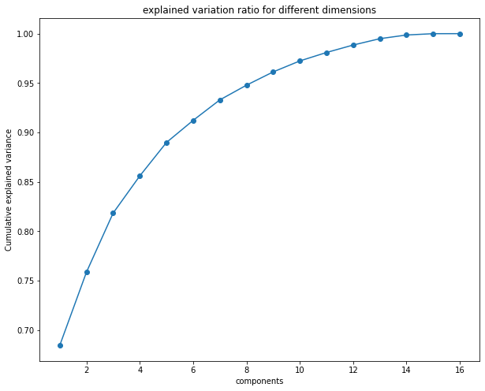

```python
#visualising the variance for number of components
import matplotlib.pyplot as plt
plt.figure(figsize=(10,8))
plt.plot(range(1,17),pca.explained_variance_ratio_.cumsum(),marker='o')
plt.title("explained variation ratio for different dimensions")
plt.xlabel("components")
plt.ylabel("Cumulative explained variance")
```

From the above plot, it is seen that, only 3 features are enough to represent 80% of variation of the data, we consider number of components for PCA as 3.

```python
#PCA fit for 3 components
pca = PCA(n_components=3)
pca.fit(df_scaled)
```

```
PCA(n_components=3)
```

```python
## PCA transform for the data frame to convert the multi dimensional data into 3 corresponding components,
## we will bw using this data for further calculating the the value of k

pca.transform(df_scaled)
scored_Pca  = pca.transform(df_scaled)
```

# **Applying K-Means Clustering**

using Internal validation to report cluster quality and finding optimum number of clusters

```python
#Elbow Method for finding the optimal no of clusters
from sklearn.cluster import KMeans
SSE =[] # Sum of Squared error value are stored here for each possible cluster

for i in range (1,11):
  kmeans_pca = KMeans(n_clusters = i,random_state=42,init="k-means++")
  kmeans_pca.fit(scored_Pca)
  SSE.append(kmeans_pca.inertia_)
```

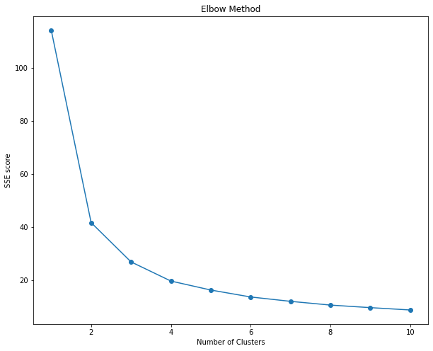

```python
#Plotting the Elbow Graph
plt.figure(figsize=(10,8))
plt.plot(range(1,11),SSE,marker='o')
plt.title("Elbow Method")
plt.xlabel("Number of Clusters")
plt.ylabel("SSE score")
plt.show()
```

Calculating the Silhoutte score for checking the cluster quality and the validate that k=2 is the right number of clusters

Silhouette Score = (b-a)/max(a,b)

where

a= average intra-cluster distance i.e the average distance between each point within a cluster.

b= average inter-cluster distance i.e the average distance between all clusters.

```python
#Calculating the Silhoutte score for checking the cluster quality and validate that k=2 is the right number of clusters
kmeans_pca = KMeans(n_clusters = 2,random_state=42,init="k-means++")
y_pred = kmeans_pca.fit(scored_Pca)
score = sklearn.metrics.silhouette_score(scored_Pca, y_pred.labels_, metric='euclidean')
#
# Print the score
#
print('Silhouette Score: %.5f' % score)
```

```
Silhouette Score: 0.52342
```

Calculating Silhoutte Score

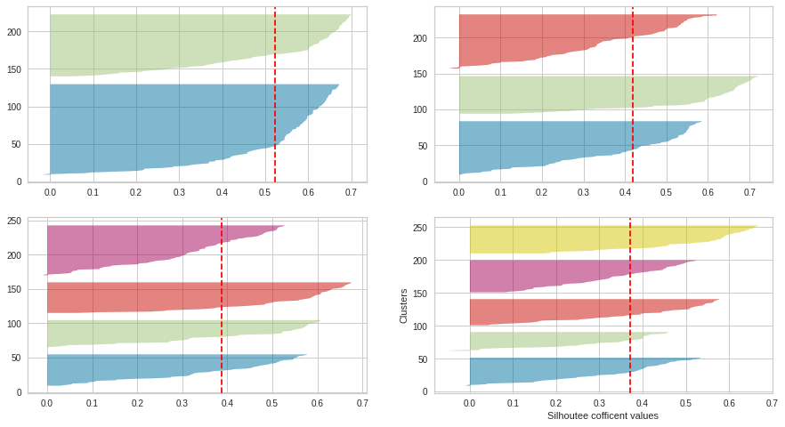

```python
#Plotting the silhouette score with respect to number of culsters to validate once again that cluster quality at k=2 is optimum

from yellowbrick.cluster import SilhouetteVisualizer

fig, ax = plt.subplots(2, 2, figsize=(15,8))
for i in [2, 3, 4, 5]:

    #Create KMeans instance for different number of clusters

    km = KMeans(n_clusters=i, init='k-means++', random_state=42)
    q, mod = divmod(i, 2)

   # Create SilhouetteVisualizer instance with KMeans instance Fit the visualizer

    visualizer = SilhouetteVisualizer(km, colors='yellowbrick', ax=ax[q-1][mod])
    visualizer.fit(scored_Pca)
    plt.xlabel("Silhoutee cofficent values")
    plt.ylabel("Clusters")
```

Insight: As we can see from the first graph, the silhouette coefficient score is better for 2 clusters

Calculating the Dunn Index

For 𝑚 clusters, the Dunn index is calculated as:

𝐷𝐼𝑚=min1≤𝑖≤𝑗≤𝑚𝛿(𝐶𝑖,𝐶𝑗)max1≤𝑘≤𝑚Δ𝑘

```python
from sklearn.metrics import pairwise_distances
from validclust import dunn
kmeans_pca = KMeans(n_clusters = 2,random_state=42,init="k-means++")
y_pred = kmeans_pca.fit(scored_Pca)
dist = pairwise_distances(scored_Pca)
print("The Dunn Value for the clusters is {dunn}".format(dunn = dunn(dist, y_pred.labels_)))# the value of Dunn Index is low because the data is overlapping
```

```
The Dunn Value for the clusters is 0.06864681215142851
```

Calinski_Harabasz_Score

The Calinski-Harabasz index is calculated as:

𝐶𝐻=𝐵𝐺𝑆𝑆𝐾−1𝑊𝐺𝑆𝑆𝑁−𝐾=𝐵𝐺𝑆𝑆𝑊𝐺𝑆𝑆×𝑁−𝐾𝐾−1 where:

𝐵𝐺𝑆𝑆 : between-group sum of squares (between-group dispersion) 𝑊𝐺𝑆𝑆 : within-group sum of squares (within-group dispersion) 𝑁 : total number of observations 𝐾 : total number of clusters

```python
from sklearn.metrics import calinski_harabasz_score
import matplotlib.pyplot as plt
results = {}

for i in range(2,11):
    kmeans_pca = KMeans(n_clusters = i,random_state=42,init="k-means++")
    y_pred = kmeans_pca.fit(scored_Pca)
    db_index = calinski_harabasz_score(scored_Pca, y_pred.labels_)
    results.update({i: db_index})
```

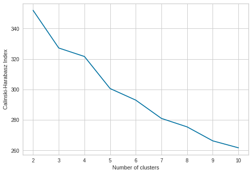

```python
#Plotting the CH score for every possible cluster, Higher the value better the cluster performance
plt.plot(list(results.keys()), list(results.values()))
plt.xlabel("Number of clusters")
plt.ylabel("Calinski-Harabasz Index")
plt.show()
```

```python
# Therefore we chose 2 as optimum number of clusters
kmeans_pca = KMeans(n_clusters = 2,random_state=42,init="k-means++")
y_pred = kmeans_pca.fit(scored_Pca)
```

```python
#adding the PCA components and the predicted cluster class to our data frame
df_pca_kmeans = pd.concat([df_with_countries.reset_index(drop=True),pd.DataFrame(scored_Pca)],axis =1)
df_pca_kmeans.columns.values[-3:]=['Component 1','Component 2','Component 3']
df_pca_kmeans['K-Means PCA cluster']=y_pred.labels_
df_pca_kmeans
```

|  | Birth Rate | Business Tax Rate | Days to Start Business | GDP | Health Exp % GDP | Health Exp/Capita | Hours to do Tax | Infant Mortality Rate | Internet Usage | Life Expectancy Female | ... | Mobile Phone Usage | Population 0-14 | Population 15-64 | Population 65+ | Population Urban | Country | Component 1 | Component 2 | Component 3 | K-Means PCA cluster |
| --- | --- | --- | --- | --- | --- | --- | --- | --- | --- | --- | --- | --- | --- | --- | --- | --- | --- | --- | --- | --- | --- |
| 0 | 0.025 | 0.720 | 25.0 | 1.990709e+11 | 0.044 | 233.0 | 451.0 | 0.023 | 0.1 | 72.0 | ... | 0.9 | 0.272 | 0.681 | 0.047 | 0.682 | Algeria | 0.145685 | -0.268272 | -0.128621 | 1 |
| 1 | 0.046 | 0.521 | 66.0 | 1.041159e+11 | 0.034 | 178.0 | 282.0 | 0.107 | 0.1 | 53.0 | ... | 0.5 | 0.477 | 0.499 | 0.024 | 0.409 | Angola | 1.315211 | 0.215036 | -0.272902 | 1 |
| 2 | 0.037 | 0.659 | 29.0 | 7.294900e+09 | 0.045 | 34.0 | 270.0 | 0.060 | 0.0 | 60.0 | ... | 0.8 | 0.432 | 0.539 | 0.029 | 0.423 | Benin | 0.934451 | 0.004042 | -0.120899 | 1 |
| 3 | 0.024 | 0.195 | 60.0 | 1.529242e+10 | 0.052 | 404.0 | 152.0 | 0.039 | 0.1 | 46.0 | ... | 1.5 | 0.340 | 0.625 | 0.035 | 0.565 | Botswana | 0.677373 | -0.069968 | -0.182503 | 1 |
| 4 | 0.042 | 0.435 | 13.0 | 1.039576e+10 | 0.064 | 39.0 | 270.0 | 0.068 | 0.0 | 56.0 | ... | 0.5 | 0.458 | 0.517 | 0.025 | 0.265 | Burkina Faso | 1.156534 | 0.158393 | 0.002191 | 1 |
| ... | ... | ... | ... | ... | ... | ... | ... | ... | ... | ... | ... | ... | ... | ... | ... | ... | ... | ... | ... | ... | ... |
| 199 | 0.015 | 0.291 | 41.0 | 2.367635e+10 | 0.053 | 935.0 | 210.0 | 0.020 | 0.6 | 73.0 | ... | 1.4 | 0.207 | 0.708 | 0.085 | 0.089 | Trinidad and Tobago | -0.156272 | -0.142515 | 0.497189 | 0 |
| 200 | 0.013 | 0.465 | 5.0 | 1.553380e+13 | 0.177 | 8467.0 | 187.0 | 0.006 | 0.7 | 81.0 | ... | 0.9 | 0.197 | 0.669 | 0.133 | 0.809 | United States | -0.840803 | 0.901668 | -0.016184 | 0 |
| 201 | 0.015 | 0.419 | 7.0 | 4.723671e+10 | 0.088 | 1213.0 | 336.0 | 0.010 | 0.5 | 80.0 | ... | 1.4 | 0.223 | 0.638 | 0.139 | 0.946 | Uruguay | -0.536395 | 0.070088 | -0.216742 | 0 |
| 202 | 0.020 | 0.628 | 141.0 | 3.164822e+11 | 0.045 | 487.0 | 864.0 | 0.014 | 0.4 | 77.0 | ... | 1.0 | 0.291 | 0.651 | 0.058 | 0.888 | Venezuela, RB | -0.159250 | -0.192093 | -0.331135 | 0 |
| 203 | 0.011 | 0.412 | 19.0 | 2.381244e+10 | 0.068 | 487.0 | 245.0 | 0.014 | 0.4 | 83.0 | ... | 1.0 | 0.206 | 0.649 | 0.145 | 0.948 | Virgin Islands (U.S.) | -0.548136 | -0.061928 | -0.151862 | 0 |

204 rows × 21 columns

# **Data Visualization and scatter plots**

```python
df_pca_kmeans["Segment"] = df_pca_kmeans["K-Means PCA cluster"].map({0:"first",1:"Second"})
```

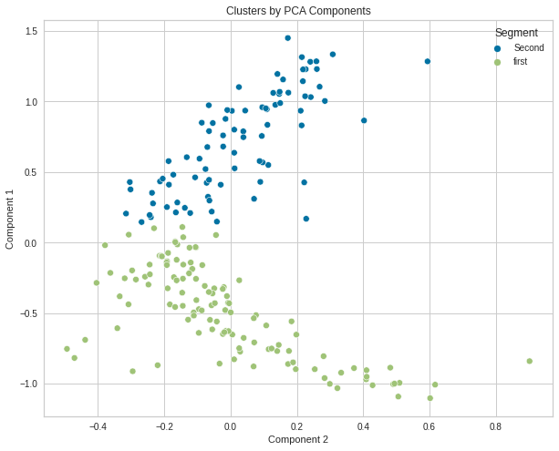

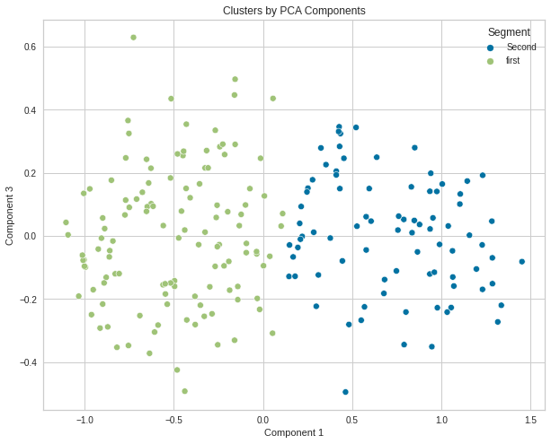

```python
#Visualising PCA Components, you could visualize any 2 components with each other to check cluster distribution for each component
x_axis=df_pca_kmeans['Component 2']
y_axis=df_pca_kmeans['Component 1']
z_axis = df_pca_kmeans['Component 3']
plt.figure(figsize=(10,8))
sns.scatterplot(x_axis, y_axis, hue=df_pca_kmeans['Segment'])
plt.title('Clusters by PCA Components')
plt.show()
plt.figure(figsize=(10,8))
sns.scatterplot(y_axis, z_axis, hue=df_pca_kmeans['Segment'])
plt.title('Clusters by PCA Components')
plt.show()
```

Scatter plot Internet Usage vs Birth rate

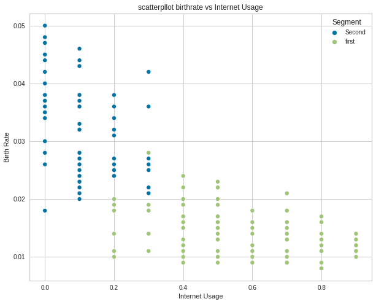

```python
x_axis=df_pca_kmeans['Internet Usage']
y_axis=df_pca_kmeans['Birth Rate']
plt.figure(figsize=(10,8))
sns.scatterplot(x_axis, y_axis, hue=df_pca_kmeans['Segment'])
plt.title('scatterpllot birthrate vs Internet Usage')
plt.show()
```

Scatter plot Life Expectancy Female vs Population Urban

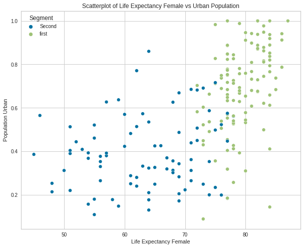

```python
x_axis=df_pca_kmeans['Life Expectancy Female']
y_axis=df_pca_kmeans['Population Urban']
plt.figure(figsize=(10,8))
sns.scatterplot(x_axis, y_axis, hue=df_pca_kmeans['Segment'])
plt.title('Scatterplot of Life Expectancy Female vs Urban Population')
plt.show()
```

Scatter plot Population 0-14 vs Population 15-64

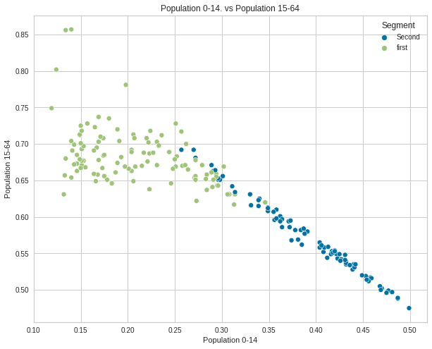

```python
x_axis=df_pca_kmeans['Population 0-14']
y_axis=df_pca_kmeans['Population 15-64']
plt.figure(figsize=(10,8))
sns.scatterplot(x_axis, y_axis, hue=df_pca_kmeans['Segment'])
plt.title('Population 0-14. vs Population 15-64')
plt.show()
```

Scatter plot Life Expectancy Male vs GDP

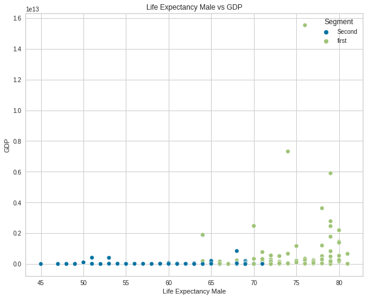

```python
x_axis=df_pca_kmeans['Life Expectancy Male']
y_axis=df_pca_kmeans['GDP']
plt.figure(figsize=(10,8))
sns.scatterplot(x_axis, y_axis, hue=df_pca_kmeans['Segment'])
plt.title('Life Expectancy Male vs GDP')
plt.show()
```

```python
#Mapping Countiries as per the Segment in K means
df_countries_cluster = df_pca_kmeans[['K-Means PCA cluster','Country']]
df_countries_cluster
```

|  | K-Means PCA cluster | Country |
| --- | --- | --- |
| 0 | 1 | Algeria |
| 1 | 1 | Angola |
| 2 | 1 | Benin |
| 3 | 1 | Botswana |
| 4 | 1 | Burkina Faso |
| ... | ... | ... |
| 199 | 0 | Trinidad and Tobago |
| 200 | 0 | United States |
| 201 | 0 | Uruguay |
| 202 | 0 | Venezuela, RB |
| 203 | 0 | Virgin Islands (U.S.) |

204 rows × 2 columns

# **Hierarchical** **Clustering**

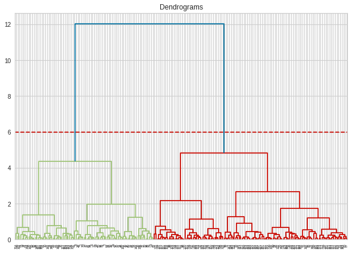

```python
#Plotting the Dendogram for the hierarchical clustering using the PCA values
plt.figure(figsize=(10, 7))
plt.title("Dendrograms")
dend = shc.dendrogram(shc.linkage(scored_Pca, method='ward'))
plt.axhline(y=6, color='r', linestyle='--')
```

After locating the horizontal line, we count how many times our vertical lines were crossed by it - in this example, 2 times. So 2 seems a good indication of the number of clusters that have the most distance between them.

# **Internal Validation for number of Clusters**

```python
#Using Hierarchical clustering to fit into our data

from sklearn.cluster import AgglomerativeClustering
clustering_model = AgglomerativeClustering(n_clusters=2, affinity='euclidean', linkage='ward')
clustering_model.fit(scored_Pca)
```

```
AgglomerativeClustering()
```

Silhouette Score

```python
#Calculating the Silhoutte score for k=2 clusters, as the dendogram clearly shows the optimum number of clusters
clustering_model = AgglomerativeClustering(n_clusters=2, affinity='euclidean', linkage='ward')
y_pred =clustering_model.fit(scored_Pca)
score = sklearn.metrics.silhouette_score(scored_Pca, y_pred.labels_, metric='euclidean')
# Print the score
print('Silhouette Score: %.3f' % score)
```

```
Silhouette Score: 0.522
```

Dunn Index

```python
#Calculating the Dunn Index, the value of the index is low in heirarchical as well because the data is overlapping
from sklearn.metrics import pairwise_distances
from validclust import dunn
clustering_model = AgglomerativeClustering(n_clusters=2, affinity='euclidean', linkage='ward')
y_pred =clustering_model.fit(scored_Pca)
dist = pairwise_distances(scored_Pca)
print("The Dunn Value for the clusters is {dunn}".format(dunn = dunn(dist, y_pred.labels_)))
```

```
The Dunn Value for the clusters is 0.07545926790719353
```

Calinski-Harabasz Index

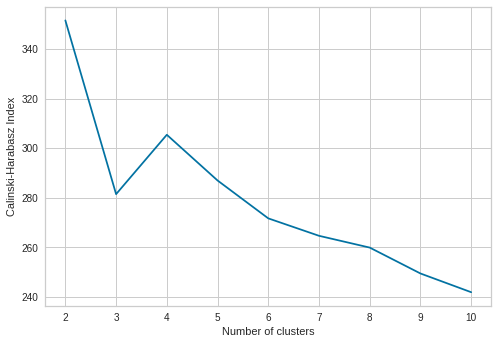

```python
#calculating the CH Index score,score is higher when clusters are dense and well separated, which relates to a standard concept of a cluster.
from sklearn.metrics import calinski_harabasz_score
import matplotlib.pyplot as plt
results = {}

for i in range(2,11):
    clustering_model = AgglomerativeClustering(n_clusters=i, affinity='euclidean', linkage='ward')
    y_pred =clustering_model.fit(scored_Pca)
    db_index = calinski_harabasz_score(scored_Pca, y_pred.labels_)
    results.update({i: db_index})


plt.plot(list(results.keys()), list(results.values()))
plt.xlabel("Number of clusters")
plt.ylabel("Calinski-Harabasz Index")
plt.show()
```

```python
#Therefore we chose 2 as optimum number of clusters
clustering_model = AgglomerativeClustering(n_clusters=2, affinity='euclidean', linkage='ward')
y_pred =clustering_model.fit(scored_Pca)
```

```python
df_pca_hierarchal = pd.concat([df_with_countries.reset_index(drop=True),pd.DataFrame(scored_Pca)],axis =1)
df_pca_hierarchal.columns.values[-3:]=['Component 1','Component 2','Component 3']
df_pca_hierarchal['hierarchal PCA cluster']=clustering_model.labels_
df_pca_hierarchal.head()
```

|  | Birth Rate | Business Tax Rate | Days to Start Business | GDP | Health Exp % GDP | Health Exp/Capita | Hours to do Tax | Infant Mortality Rate | Internet Usage | Life Expectancy Female | ... | Mobile Phone Usage | Population 0-14 | Population 15-64 | Population 65+ | Population Urban | Country | Component 1 | Component 2 | Component 3 | hierarchal PCA cluster |
| --- | --- | --- | --- | --- | --- | --- | --- | --- | --- | --- | --- | --- | --- | --- | --- | --- | --- | --- | --- | --- | --- |
| 0 | 0.025 | 0.720 | 25.0 | 1.990709e+11 | 0.044 | 233.0 | 451.0 | 0.023 | 0.1 | 72.0 | ... | 0.9 | 0.272 | 0.681 | 0.047 | 0.682 | Algeria | 0.145685 | -0.268272 | -0.128621 | 1 |
| 1 | 0.046 | 0.521 | 66.0 | 1.041159e+11 | 0.034 | 178.0 | 282.0 | 0.107 | 0.1 | 53.0 | ... | 0.5 | 0.477 | 0.499 | 0.024 | 0.409 | Angola | 1.315211 | 0.215036 | -0.272902 | 1 |
| 2 | 0.037 | 0.659 | 29.0 | 7.294900e+09 | 0.045 | 34.0 | 270.0 | 0.060 | 0.0 | 60.0 | ... | 0.8 | 0.432 | 0.539 | 0.029 | 0.423 | Benin | 0.934451 | 0.004042 | -0.120899 | 1 |
| 3 | 0.024 | 0.195 | 60.0 | 1.529242e+10 | 0.052 | 404.0 | 152.0 | 0.039 | 0.1 | 46.0 | ... | 1.5 | 0.340 | 0.625 | 0.035 | 0.565 | Botswana | 0.677373 | -0.069968 | -0.182503 | 1 |
| 4 | 0.042 | 0.435 | 13.0 | 1.039576e+10 | 0.064 | 39.0 | 270.0 | 0.068 | 0.0 | 56.0 | ... | 0.5 | 0.458 | 0.517 | 0.025 | 0.265 | Burkina Faso | 1.156534 | 0.158393 | 0.002191 | 1 |

5 rows × 21 columns

```python
df_pca_hierarchal["Segment"] = df_pca_hierarchal["hierarchal PCA cluster"].map({0:"first",1:"Second"})
```